# 개별 프로젝트 - 김희범

## CNN을 이용하여 10개의 카테고리의 분류에 대한 기계학습.

작성일시: 2019.08.20  
참고: https://qiita.com/God_KonaBanana/items/10fa8bb58cdd1dbd2e59  
번역: 김희범

참고코드를 그대로 사용하지않고, 일부분을 수정하였습니다.

### cifar10とKerasを使ってCNN(Convolutional Neural Network)を実装してみる

cifat10과 Keras를 이용하여 CNN 신경망을 구현해보기

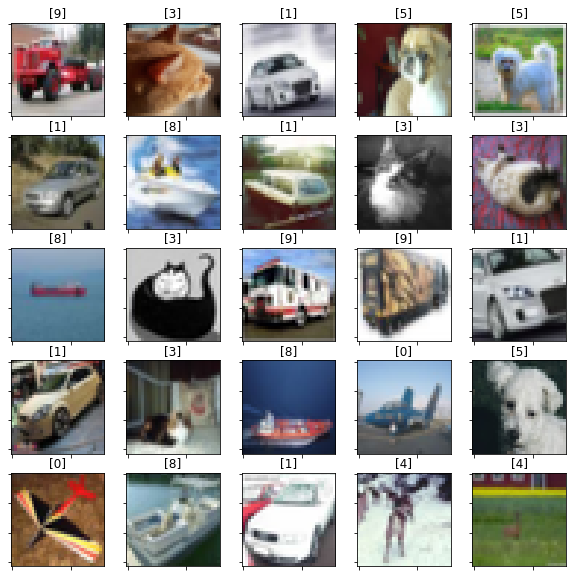

```python
# from keras.datasets import cifar10
import matplotlib.pyplot as plt
import numpy as np

(x_train,y_train),(x_test,y_test)=cifar10.load_data()

#6x6枚の画像を表示する (6x6 사진을 표시하기)
plt.figure(figsize=(10,10))
for i in range(25):
    rand_num=np.random.randint(0,50000) #50000장의 학습 셋 데이터.
    cifar_img=plt.subplot(5,5,i+1)
    plt.imshow(x_train[rand_num])
    #x軸の目盛りを消す (x축의 눈금을 제거합니다.)
    plt.tick_params(labelbottom='off')
    #y軸の目盛りを消す (y축의 눈금을 제거합니다.)
    plt.tick_params(labelleft='off')
    #正解ラベルを表示 (올바른 라벨을 표시합니다.)
    plt.title(y_train[rand_num])

plt.show()
```

画像は32x32のRGBです。画像の上に表示されている数字が正解ラベル。  
그림은 32x32의 RGB 형태이며, 그림 위에 표시된 숫자가 라벨입니다.

0 - airplane  
1 - automobile  
2 - bird  
3 - cat  
4 - deer  
5 - dog  
6 - frog  
7 - horse  
8 - ship  
9 - truck

ラベルはこのようになっています。  
라벨은 이와같이 구성되어 있습니다.

# CNNを実装

CNN 구축하기

必要なライブラリのインポートと画像の前処理  
필요한 라이브러리의 import와 데이터 전처리

```python
from keras.models import Sequential
from keras.layers.convolutional import Conv2D
from keras.layers.pooling import MaxPool2D
from keras.layers.core import Dense,Activation,Dropout,Flatten
from keras.datasets import cifar10
from keras.utils import np_utils

#cifar10をダウンロード (cifat10 다운로드)
(x_train,y_train),(x_test,y_test)=cifar10.load_data()

#画像を0-1の範囲で正規化 (그림을 0에서 1사이의 실수로 정규분포화.)
x_train=x_train.astype('float64')/255.0
x_test=x_test.astype('float64')/255.0

#正解ラベルをOne-Hot表現に変換 (정규화된 라벨을 원핫 인코딩으로 변환.)
y_train=np_utils.to_categorical(y_train,10)
y_test=np_utils.to_categorical(y_test,10)
```

訓練データ5万枚、テストデータ1万枚をダウンロードします。  
훈련용 데이터 5만장, 테스트용 데이터 1만장을 다운받습니다.

画像は、縦横32x32、0-255のRGBなので255で割って0-1で正規化します。  
그림은, 가로세로 32픽셀, 0-255범위의 RGB색상이므로 255로 나누고, 정규화를 합니다.

y_train,y_testはOne-Hot表現に変換します。  
y_train,y_test변수는 원핫 인코딩으로 바꾸어줍니다.

One-Hot表現とは、カテゴリが10のときは例えば、  
원핫 인코딩의 표현이란, 카테고리가 10개 일때 예로 들면,  
4 → [0,0,0,0,1,0,0,0,0,0]  
0 → [1,0,0,0,0,0,0,0,0,0]  
8 → [0,0,0,0,0,0,0,0,1,0]

といった表現です。  
이와 같은 표현입니다.

```python
#モデルを構築 (모델 만들기)
model=Sequential()

model.add(Conv2D(32,(3,3),padding='same',input_shape=(32,32,3)))
model.add(Activation('relu'))  # 활성화 함수로 relu함수 사용.
model.add(Conv2D(32,(3,3),padding='same'))
model.add(Activation('relu'))
model.add(MaxPool2D(pool_size=(2,2)))
model.add(Dropout(0.25)) # 25%의 노드 끄기.

model.add(Conv2D(64,(3,3),padding='same'))
model.add(Activation('relu'))
model.add(Conv2D(64,(3,3),padding='same'))
model.add(Activation('relu'))
model.add(MaxPool2D(pool_size=(2,2)))
model.add(Dropout(0.25)) # 25%의 노드 끄기.

model.add(Flatten())
model.add(Dense(512))  # 512개의 은닉층
model.add(Activation('relu'))
model.add(Dropout(0.5)) # 50%의 노드 끄기.
model.add(Dense(10,activation='softmax'))

model.compile(optimizer='adam',loss='categorical_crossentropy',metrics=['accuracy'])

history=model.fit(x_train,y_train,batch_size=64,nb_epoch=100,verbose=1,validation_split=0.2) #20%는 테스트용 데이터.

#モデルと重みを保存 (모델과 용량을 보존)
json_string=model.to_json()
open('cifar10_cnn.json',"w").write(json_string)
model.save_weights('cifar10_cnn.h5')

#モデルの表示 (모델 표시하기)
model.summary()

#評価 (평가)
score=model.evaluate(x_test,y_test,verbose=0)
print('Test loss:',score[0])
print('Test accuracy:',score[1]) #정확도.
```

```
Train on 40000 samples, validate on 10000 samples
_________________________________________________________________
Layer (type)                 Output Shape              Param #
=================================================================
conv2d_61 (Conv2D)           (None, 32, 32, 32)        896
_________________________________________________________________
activation_76 (Activation)   (None, 32, 32, 32)        0
_________________________________________________________________
conv2d_62 (Conv2D)           (None, 32, 32, 32)        9248
_________________________________________________________________
activation_77 (Activation)   (None, 32, 32, 32)        0
_________________________________________________________________
max_pooling2d_31 (MaxPooling (None, 16, 16, 32)        0
_________________________________________________________________
dropout_46 (Dropout)         (None, 16, 16, 32)        0
_________________________________________________________________
conv2d_63 (Conv2D)           (None, 16, 16, 64)        18496
_________________________________________________________________
activation_78 (Activation)   (None, 16, 16, 64)        0
_________________________________________________________________
conv2d_64 (Conv2D)           (None, 16, 16, 64)        36928
_________________________________________________________________
activation_79 (Activation)   (None, 16, 16, 64)        0
_________________________________________________________________
max_pooling2d_32 (MaxPooling (None, 8, 8, 64)          0
_________________________________________________________________
dropout_47 (Dropout)         (None, 8, 8, 64)          0
_________________________________________________________________
flatten_16 (Flatten)         (None, 4096)              0
_________________________________________________________________
dense_31 (Dense)             (None, 512)               2097664
_________________________________________________________________
activation_80 (Activation)   (None, 512)               0
_________________________________________________________________
dropout_48 (Dropout)         (None, 512)               0
_________________________________________________________________
dense_32 (Dense)             (None, 10)                5130
=================================================================
Total params: 2,168,362
Trainable params: 2,168,362
Non-trainable params: 0
_________________________________________________________________
Test loss: 0.9351257470369339
Test accuracy: 0.7875
```

```python
json_string=model.to_json()
open('cifar10_cnn.json',"w").write(json_string)
model.save_weights('cifar10_cnn.h5')
```

## model.predict_classesを使って予測

model.predict_classes 모듈을 이용하여 그림 예측하기

model.predict_classesを使って、テストデータの画像を何枚か抽出して写っているものを予測したいと思います。  
model.predict_classes을 사용해서 테스트 셋의 그림을 여러장 추출하여 사진을 예측해보겠습니다.

さきほど実装したスクリプトを実行すると、同じ階層のフォルダにモデルと重みが記録されたファイルが生成されていると思います。  
앞서 실행한 스크립트를 불러오면, 같은 디렉토리에 모델과 파일이 저장되어 있을 겁니다.

"cifar10_cnn.json"がモデルの記録されたファイルで、"cifar10_cnn.h5"が重みの記録されたファイルです。  
"cifar10_cnn.json"파일이 모델을 기록한 것이고, "cifar10_cnn.h5"가 그림의 weight가 기록된 파일입니다.

これらの学習済みのファイルを使えば、2回目以降は一からモデルを構築したり、長ったらしい学習の計算をする必要がなくなります。  
학습이 끝난 데이터들을 사용하면, 두번째부터는 바닥부터 모델을 만들고 긴 학습을 할 필요가 없어집니다.

10000枚のテスト画像の中から25枚をランダムに抽出して、それを学習済みモデルからmodel.predict_classesを使って画像の被写体を予測します。  
10000장의 테스트 셋 중에서 25장을 임의로 추출하여, 학습이 끝난 모델로부터 model.predict_classes을 써서 그림의 형태를 예측합니다.

```
_________________________________________________________________
Layer (type)                 Output Shape              Param #
=================================================================
conv2d_17 (Conv2D)           (None, 32, 32, 32)        896
_________________________________________________________________
activation_21 (Activation)   (None, 32, 32, 32)        0
_________________________________________________________________
conv2d_18 (Conv2D)           (None, 32, 32, 32)        9248
_________________________________________________________________
activation_22 (Activation)   (None, 32, 32, 32)        0
_________________________________________________________________
max_pooling2d_9 (MaxPooling2 (None, 16, 16, 32)        0
_________________________________________________________________
dropout_13 (Dropout)         (None, 16, 16, 32)        0
_________________________________________________________________
conv2d_19 (Conv2D)           (None, 16, 16, 64)        18496
_________________________________________________________________
activation_23 (Activation)   (None, 16, 16, 64)        0
_________________________________________________________________
conv2d_20 (Conv2D)           (None, 16, 16, 64)        36928
_________________________________________________________________
activation_24 (Activation)   (None, 16, 16, 64)        0
_________________________________________________________________
max_pooling2d_10 (MaxPooling (None, 8, 8, 64)          0
_________________________________________________________________
dropout_14 (Dropout)         (None, 8, 8, 64)          0
_________________________________________________________________
flatten_5 (Flatten)          (None, 4096)              0
_________________________________________________________________
dense_9 (Dense)              (None, 512)               2097664
_________________________________________________________________
activation_25 (Activation)   (None, 512)               0
_________________________________________________________________
dropout_15 (Dropout)         (None, 512)               0
_________________________________________________________________
dense_10 (Dense)             (None, 10)                5130
=================================================================
Total params: 2,168,362
Trainable params: 2,168,362
Non-trainable params: 0
_________________________________________________________________
Test loss: 0.7682604624271393
Test accuracy: 0.7965
```

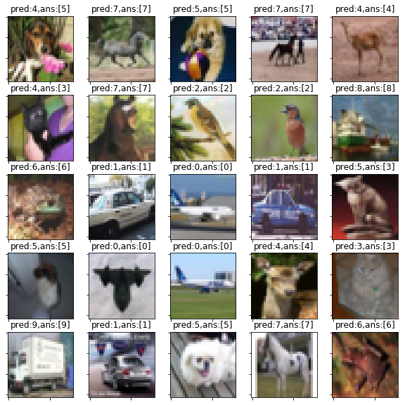

```python
from keras.datasets import cifar10
from keras.models import model_from_json
from keras.utils import np_utils
import matplotlib.pyplot as plt
import numpy as np

#cifar10をダウンロード (cifar10을 다운로드)
(_,_),(x_test_img,y_test_img)=cifar10.load_data()

#画像を0-1の範囲で正規化 (그림을 0과 1사이의 실수로 정규화.)
x_test=x_test_img.astype('float64')/255.0

#正解ラベルをOne-Hot表現に変換 (원핫 인코딩으로 표현)
y_test=np_utils.to_categorical(y_test_img,10)

#学習済みのモデルと重みを読み込む (학습이 끝난 모델을 불러오기)
json_string=open('cifar10_cnn.json').read()
model=model_from_json(json_string)
model.compile(optimizer='adam',loss='categorical_crossentropy',metrics=['accuracy'])
model.load_weights('cifar10_cnn.h5')

#モデルを表示 (모델을 표시.)
model.summary()

#評価 (평가.)
score=model.evaluate(x_test,y_test,verbose=0)
print('Test loss:',score[0])
print('Test accuracy:',score[1])

#predict_classesで画像のクラスを予想する (predict_classes로 그림의 종류를 예상하기)
img_pred=model.predict_classes(x_test)

#5x5枚の画像を表示する (5x5 형태로 그림을 표시하기.)
plt.figure(figsize=(10,10))
for i in range(25):
    rand_num=np.random.randint(0,10000)
    cifar_img=plt.subplot(5,5,i+1)
    plt.imshow(x_test_img[rand_num])
    #x軸の目盛りを消す (x축 눈금 제거)
    plt.tick_params(labelbottom='off')
    #y軸の目盛りを消す (y축 눈금 제거)
    plt.tick_params(labelleft='off')
    #画像の予想 (그림 예상: pred는 예측, ans는 정답.)
    plt.title('pred:{0},ans:{1}'.format(img_pred[rand_num],y_test_img[rand_num]))

plt.show()
```

### 拾った画像を使って予測する。

인터넷에서 가져온 이미지를 이용해서 예측해보기.

```
_________________________________________________________________
Layer (type)                 Output Shape              Param #
=================================================================
conv2d_17 (Conv2D)           (None, 32, 32, 32)        896
_________________________________________________________________
activation_21 (Activation)   (None, 32, 32, 32)        0
_________________________________________________________________
conv2d_18 (Conv2D)           (None, 32, 32, 32)        9248
_________________________________________________________________
activation_22 (Activation)   (None, 32, 32, 32)        0
_________________________________________________________________
max_pooling2d_9 (MaxPooling2 (None, 16, 16, 32)        0
_________________________________________________________________
dropout_13 (Dropout)         (None, 16, 16, 32)        0
_________________________________________________________________
conv2d_19 (Conv2D)           (None, 16, 16, 64)        18496
_________________________________________________________________
activation_23 (Activation)   (None, 16, 16, 64)        0
_________________________________________________________________
conv2d_20 (Conv2D)           (None, 16, 16, 64)        36928
_________________________________________________________________
activation_24 (Activation)   (None, 16, 16, 64)        0
_________________________________________________________________
max_pooling2d_10 (MaxPooling (None, 8, 8, 64)          0
_________________________________________________________________
dropout_14 (Dropout)         (None, 8, 8, 64)          0
_________________________________________________________________
flatten_5 (Flatten)          (None, 4096)              0
_________________________________________________________________
dense_9 (Dense)              (None, 512)               2097664
_________________________________________________________________
activation_25 (Activation)   (None, 512)               0
_________________________________________________________________
dropout_15 (Dropout)         (None, 512)               0
_________________________________________________________________
dense_10 (Dense)             (None, 10)                5130
=================================================================
Total params: 2,168,362
Trainable params: 2,168,362
Non-trainable params: 0
_________________________________________________________________

predict_classes= [9]
```

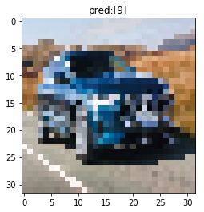

```python
from keras.models import model_from_json
import matplotlib.pyplot as plt
from keras.preprocessing.image import img_to_array, load_img

#画像読み込み 그림 불러오기
temp_img=load_img("./image/image1.jpg",target_size=(32,32))

#画像を配列に変換し0-1で正規化 그림을 배열로 바꾸고, 0-1사이의 실수로 정규화.
temp_img_array=img_to_array(temp_img)
temp_img_array=temp_img_array.astype('float64')/255.0
temp_img_array=temp_img_array.reshape((1,32,32,3))

#学習済みのモデルと重みを読み込む 학습이 끝난 모델과 weight를 불러오기.
json_string=open('cifar10_cnn.json').read()
model=model_from_json(json_string)
model.compile(optimizer='adam',loss='categorical_crossentropy',metrics=['accuracy'])
model.load_weights('cifar10_cnn.h5')

#モデルを表示 모델 표시
model.summary()

#画像を予想 그림 예측
img_pred=model.predict_classes(temp_img_array)
print('\npredict_classes=',img_pred)

plt.imshow(temp_img)
plt.title('pred:{}'.format(img_pred))
plt.show()
```

# CIFAR-100

참고: http://uchidama.hatenablog.com/entry/2018/01/22/064500

```python
from __future__ import print_function
import keras
from keras.datasets import cifar100
from keras.preprocessing.image import ImageDataGenerator
from keras.models import Sequential
from keras.layers import Dense, Dropout, Activation, Flatten
from keras.layers import Conv2D, MaxPooling2D
import os
import numpy as np

import matplotlib.pyplot as plt
from matplotlib import cm
%matplotlib inline

import random
```

```python
(x_train, y_train), (x_test, y_test) = cifar100.load_data(label_mode='fine')
print('x_train shape:', x_train.shape)
print(x_train.shape[0], 'train samples')
print(x_test.shape[0], 'test samples')

print(x_train.shape, y_train.shape)
print(x_test.shape, y_test.shape)
print(type(x_test))
print(type(y_test[0]))
```

```
Downloading data from https://www.cs.toronto.edu/~kriz/cifar-100-python.tar.gz
x_train shape: (50000, 32, 32, 3)
50000 train samples
10000 test samples
(50000, 32, 32, 3) (50000, 1)
(10000, 32, 32, 3) (10000, 1)
<class 'numpy.ndarray'>
<class 'numpy.ndarray'>
```

```python
CIFAR100_LABELS_LIST = [
    'apple', 'aquarium_fish', 'baby', 'bear', 'beaver', 'bed', 'bee', 'beetle',
    'bicycle', 'bottle', 'bowl', 'boy', 'bridge', 'bus', 'butterfly', 'camel',
    'can', 'castle', 'caterpillar', 'cattle', 'chair', 'chimpanzee', 'clock',
    'cloud', 'cockroach', 'couch', 'crab', 'crocodile', 'cup', 'dinosaur',
    'dolphin', 'elephant', 'flatfish', 'forest', 'fox', 'girl', 'hamster',
    'house', 'kangaroo', 'keyboard', 'lamp', 'lawn_mower', 'leopard', 'lion',
    'lizard', 'lobster', 'man', 'maple_tree', 'motorcycle', 'mountain', 'mouse',
    'mushroom', 'oak_tree', 'orange', 'orchid', 'otter', 'palm_tree', 'pear',
    'pickup_truck', 'pine_tree', 'plain', 'plate', 'poppy', 'porcupine',
    'possum', 'rabbit', 'raccoon', 'ray', 'road', 'rocket', 'rose',
    'sea', 'seal', 'shark', 'shrew', 'skunk', 'skyscraper', 'snail', 'snake',
    'spider', 'squirrel', 'streetcar', 'sunflower', 'sweet_pepper', 'table',
    'tank', 'telephone', 'television', 'tiger', 'tractor', 'train', 'trout',
    'tulip', 'turtle', 'wardrobe', 'whale', 'willow_tree', 'wolf', 'woman',
    'worm'
]
```

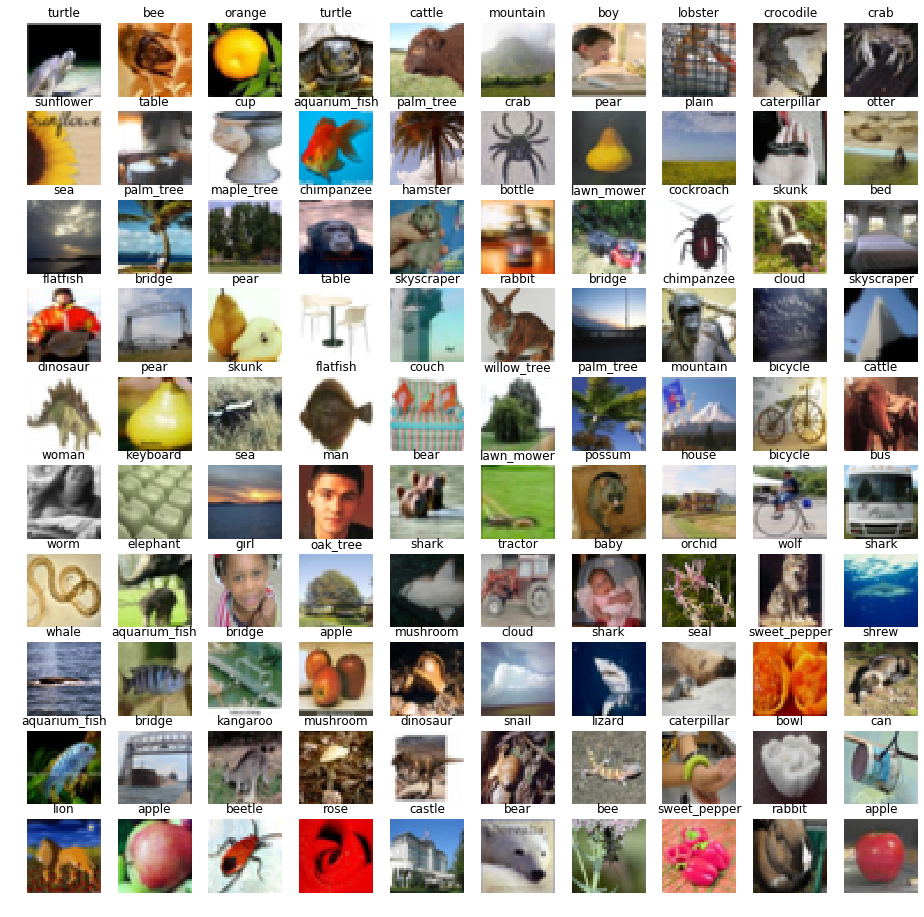

```python
pos = 1
#index = 0
index = random.randint(0, x_test.shape[0]/2)
i = index


# plt figure set to 16inch x 16inch(1600pixel x 1600 pixel).
plt.figure(figsize=(16,16))

# draw cifar100 images and label names
for img in x_test[index:index+100]:
    plt.subplot(10, 10, pos)
    plt.imshow(img)
    plt.axis('off')
    plt.title(CIFAR100_LABELS_LIST[y_test[i][0]])
    pos += 1
    i += 1

plt.show()
```

```python
from keras.models import Sequential
from keras.layers.convolutional import Conv2D
from keras.layers.pooling import MaxPool2D
from keras.layers.core import Dense,Activation,Dropout,Flatten
from keras.datasets import cifar100
from keras.utils import np_utils

#cifar10をダウンロード (cifat10 다운로드)
(x_train,y_train),(x_test,y_test)=cifar100.load_data()

#画像を0-1の範囲で正規化 (그림을 0에서 1사이의 실수로 정규분포화.)
x_train=x_train.astype('float64')/255.0
x_test=x_test.astype('float64')/255.0

#正解ラベルをOne-Hot表現に変換 (정규화된 라벨을 원핫 인코딩으로 변환.)
y_train=np_utils.to_categorical(y_train,100)
y_test=np_utils.to_categorical(y_test,100)
```

```python
#モデルを構築 (모델 만들기)
model=Sequential()

model.add(Conv2D(32,(3,3),padding='same',input_shape=(32,32,3)))
model.add(Activation('relu'))  # 활성화 함수로 relu함수 사용.
model.add(Conv2D(32,(3,3),padding='same'))
model.add(Activation('relu'))
model.add(MaxPool2D(pool_size=(2,2)))
model.add(Dropout(0.25)) # 25%의 노드 끄기.

model.add(Conv2D(64,(3,3),padding='same'))
model.add(Activation('relu'))
model.add(Conv2D(64,(3,3),padding='same'))
model.add(Activation('relu'))
model.add(MaxPool2D(pool_size=(2,2)))
model.add(Dropout(0.25)) # 25%의 노드 끄기.

model.add(Flatten())
model.add(Dense(512))  # 512개의 은닉층
model.add(Activation('relu'))
model.add(Dropout(0.5)) # 50%의 노드 끄기.
model.add(Dense(100,activation='softmax'))

model.compile(optimizer='adam',loss='categorical_crossentropy',metrics=['accuracy'])

history=model.fit(x_train,y_train,batch_size=64,nb_epoch=100,verbose=1,validation_split=0.2) #20%는 테스트용 데이터.

#モデルと重みを保存 (모델과 용량을 보존)
json_string=model.to_json()
open('cifar100_cnn.json',"w").write(json_string)
model.save_weights('cifar100_cnn.h5')

#モデルの表示 (모델 표시하기)
model.summary()

#評価 (평가)
score=model.evaluate(x_test,y_test,verbose=0)
print('Test loss:',score[0])
print('Test accuracy:',score[1]) #정확도.
```

[output not shown]

```
Train on 40000 samples, validate on 10000 samples
_________________________________________________________________
Layer (type)                 Output Shape              Param #
=================================================================
conv2d_1 (Conv2D)            (None, 32, 32, 32)        896
_________________________________________________________________
activation_1 (Activation)    (None, 32, 32, 32)        0
_________________________________________________________________
conv2d_2 (Conv2D)            (None, 32, 32, 32)        9248
_________________________________________________________________
activation_2 (Activation)    (None, 32, 32, 32)        0
_________________________________________________________________
max_pooling2d_1 (MaxPooling2 (None, 16, 16, 32)        0
_________________________________________________________________
dropout_1 (Dropout)          (None, 16, 16, 32)        0
_________________________________________________________________
conv2d_3 (Conv2D)            (None, 16, 16, 64)        18496
_________________________________________________________________
activation_3 (Activation)    (None, 16, 16, 64)        0
_________________________________________________________________
conv2d_4 (Conv2D)            (None, 16, 16, 64)        36928
_________________________________________________________________
activation_4 (Activation)    (None, 16, 16, 64)        0
_________________________________________________________________
max_pooling2d_2 (MaxPooling2 (None, 8, 8, 64)          0
_________________________________________________________________
dropout_2 (Dropout)          (None, 8, 8, 64)          0
_________________________________________________________________
flatten_1 (Flatten)          (None, 4096)              0
_________________________________________________________________
dense_1 (Dense)              (None, 512)               2097664
_________________________________________________________________
activation_5 (Activation)    (None, 512)               0
_________________________________________________________________
dropout_3 (Dropout)          (None, 512)               0
_________________________________________________________________
dense_2 (Dense)              (None, 100)               51300
=================================================================
Total params: 2,214,532
Trainable params: 2,214,532
Non-trainable params: 0
_________________________________________________________________
Test loss: 2.758985285949707
Test accuracy: 0.439
```